# Partie 3/3 : Apprentissage actif pour les données textuelles

François HU - Data scientist au DataLab de la Société Générale Assurances - *19/11/19* - https://nbviewer.jupyter.org/github/curiousML/DSA/tree/master/text_mining/

```python
from IPython.display import HTML, Image
HTML('''<script>code_show=true; function code_toggle() {if (code_show){$('div.input').hide();} else {$('div.input').show();}code_show = !code_show} $( document ).ready(code_toggle);</script><form action="javascript:code_toggle()"><input type="submit" value="cacher / afficher code"></form>''')
```

```python
from jyquickhelper import add_notebook_menu
add_notebook_menu()
```

run previous cell, wait for 2 seconds

## 1. Contexte et objectifs

- **Classifier automatiquement des données textuelles volumineuses** : ces données sont labellisées par des experts humain (dans la littérature : "**oracles**")

Processus classique d'apprentissage statistique passif (**passive machine learning**) :

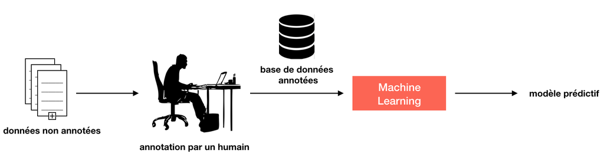

```python
Image("img/passive_learning.png", width=600)
```

- **Problèmes** : processus d'annotation peut être trop **long**, trop **difficile** et/ou trop **coûteux**
- **Question** : pouvons-nous entraîner les modèles avec $\color{red}{\text{moins de données annotées}}$ et avec $\color{red}{\text{moins d'intervention humaine}}$ ?

## 2. Active Learning

- $\color{#228B22}{\text{Active Learning}}$ : Modèle plus performant avec moins d'entraînement si nous avons la possibilité de choisir les données à entraîner

Processus d'apprentissage statistique actif (**active machine learning**) :

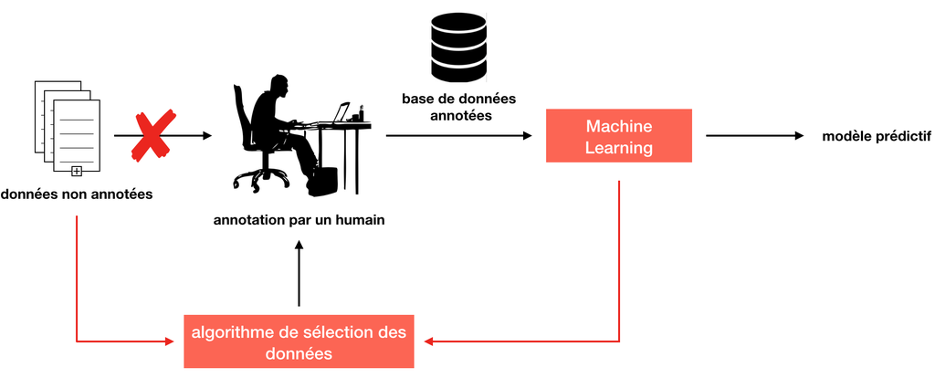

```python
Image("img/active_learning.png", width=600)
```

- Pour l'apprenant actif (active learner), il existe différentes **stratégies de requête** pour décider la donnée la plus informative (nous voulons éviter de requêter sur des données redondantes ou non-informatives)

## 3. Stratégies d'échantillonnage

**Notations** (supposons que nous avons un petit ensemble de données labélisées) :

- $x_A^*$ l'instance la plus informative (i.e. la meilleure requête) selon une stratégie de séléction $A$ ;
- $\mathcal{L} = \{x_i^*, y_i\}_{i = 1, \cdots, |\mathcal{L}|} $, l'ensemble des données labellisées ;
- $\mathcal{U} = \{x_i\}_{i = 1, \cdots, |\mathcal{U}|}$, l'ensemble des données non labellisées ;
- $\theta$, le modèle actuel ;
- $\mathcal{C}$, l'ensemble des labels. Dans le cas binaire, les classes 0 et 1 (ou -1 et 1) sont souvent utilisées

nous allons voir **deux stratégies classiques** : échantillonnage **basé sur l'incertitude du modèle** et échantillonnage **basé sur le désaccord des modèles**

### Echantillonnage basé sur l'incertitude (Uncertainty-based sampling)

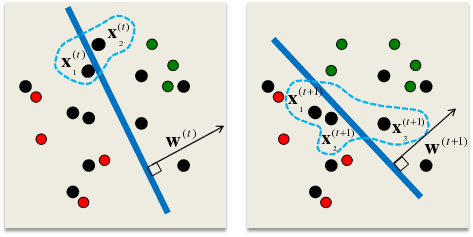

```python
Image("img/SVM_AL_US_tong_koller.png", width=800, height=200)
```

(Prateek Jain, Sudheendra Vijayanarasimhan et Kristen Grauman)

**Echantillonnage "*least confident*"**

- L'apprenant actif requête les instances pour lesquelles il n'est pas certain comment labelliser (Lewis and Gale, 1994).
- Dans le cas d'un problème de :
  - **classification binaire**, l'échantillonnage incertain requête les instances où leur probabilité à posteriori d'être positif est proche de 0.5
  - **classification multi-classe**, l'échantillonnage incertain requête les instances où leur prédiction est la moins confiante

    $$x_{LC}^* = \arg\max_{x \in \mathcal{U}}\left\{ 1 - P_{\theta}(\hat{y} \ | \ x)\right\}$$

    où $\hat{y} = \arg\max\limits_{y}\left\{ P_{\theta}(y\ |\ x)\right\}$ est la classe avec la plus grande probabilité à postériori sous le modèle $\theta$.

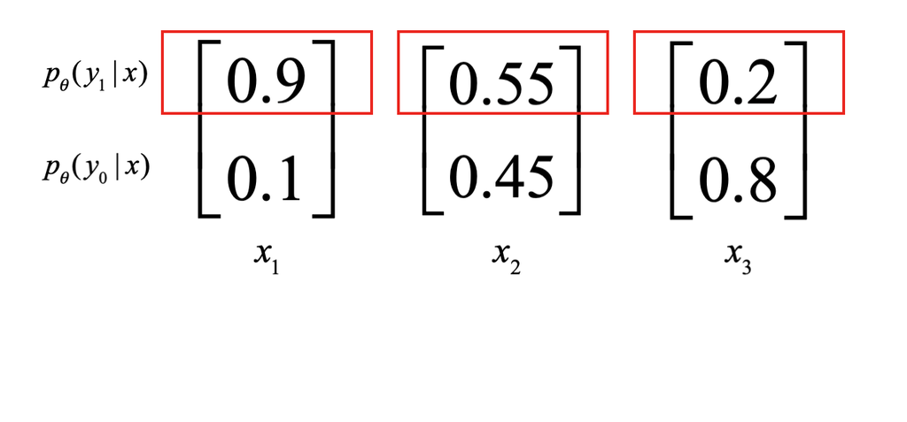

```python
Image("img/uncertainty_binary.png", width=800, height=200)
```

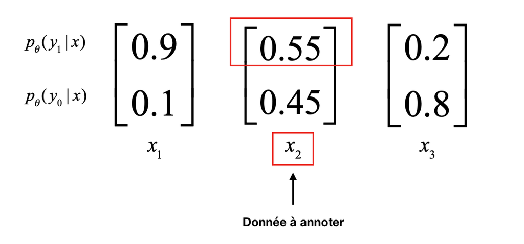

```python
Image("img/uncertainty_binary_select.png", width=800, height=200)
```

Cette stratégie considère seulement l'information sur le label le plus probable mais ne tient pas en compte les autres labels

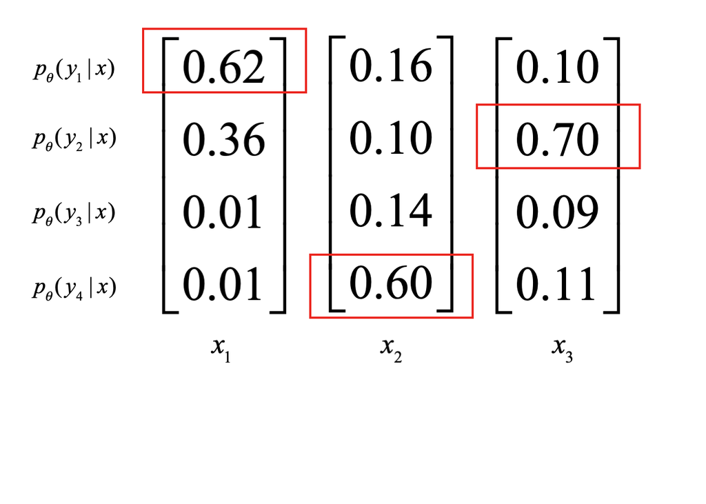

```python
Image("img/uncertainty_multi1.png", width=800, height=200)
```

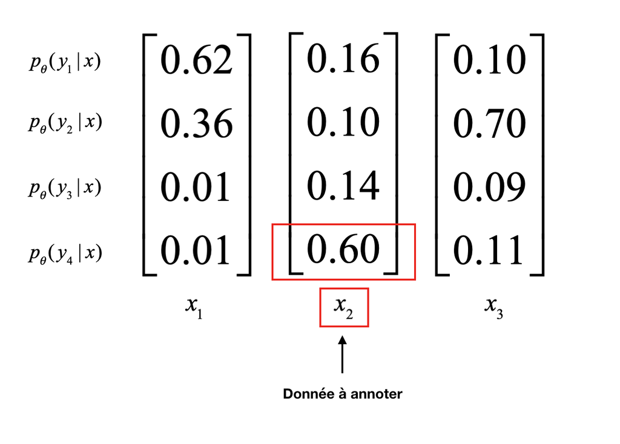

```python
Image("img/uncertainty_multi2.png", width=800, height=200)
```

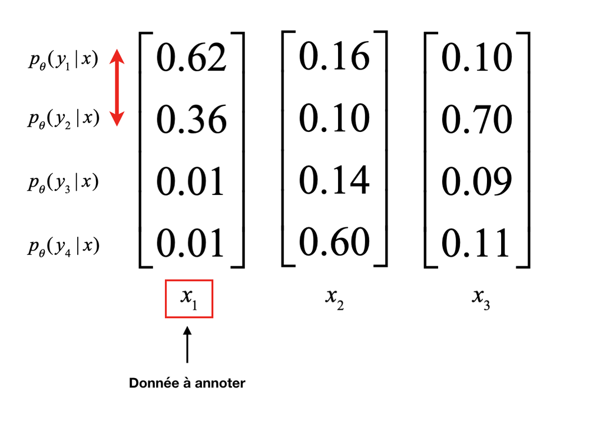

```python
Image("img/uncertainty_multi3.png", width=800, height=200)
```

**Echantillonnage avec marge**

- (Scheffer et al, 2001) propose une stratégie pour remédier ce problème : l'**échantillonnage avec marge** (**margin sampling**)

**Echantillonnage par entropie**

- Une stratégie d'échantillonnage incertain plus générale (Shannon, 1948) utilise l'**entropie** comme mesure d'incertitude

  $$x_{H}^* = \arg\max_{x \in \mathcal{U}}\left\{ - \sum\limits_{i=1}^{|\mathcal{C}|}P_{\theta}(y_i \ | \ x)\log P_{\theta}(y_i \ | \ x)\right\}$$
- Une entropie est une mesure d'information théorique qui représente la quantité d'information nécessaire pour "encoder" une distribution
- Pour une classification binaire, les trois stratégies ci-dessus sont équivalentes
- Pour une classification multi-classe, l'approche entropique se généralise bien (voir Setteles et Craven (2008), pour les travaux sur les séquences)
- Intuitivement :
  - l'entropie semble être plus appropriée si la fonction objectif est de minimiser la **perte logistique** (**log-loss**)
  - l'échantillonnage incertain et l'échantillonnage de marge semblent plus appropriées si nous voulons réduire l'**erreur de classification** (**accuracy**).

### Echantillonnage basé sur le désaccord (Query by committee)

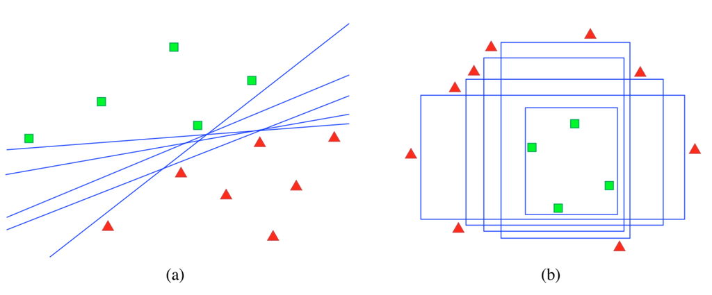

```python
Image("img/AL_QBC.png", width=800, height=200)
```

(Settles, 2010)

- L'approche QBC (Seung et al., 1992) consiste à **mettre en place, entraîner et maintenir** plusieurs modèles d'apprenant $\Theta = \{\theta^{(1)},\cdots, \theta^{(N)} \}$.
- Pour $i\in\{1, \cdots, C\}$, chaque modèle $\theta^{(i)}$ peut voter sur le label de chaque candidat de la requête
- La requête la plus informative est l'**instance où les modèles sont le plus en désaccord**
- **Objectif en apprentissage :** donner le meilleur modèle dans l'espace de versions. **Objectif en apprentissage actif :** contraindre le plus possible la taille de l'espace avec le moins d'instances labellisées que possible.
- Afin d'implémenter un algorithme de séléction QBC nous devons préalablement :
  1. construire un comité de modèles qui représentent différentes régions de l'espace des versions (Mitchelle, 1982).
  2. avoir une mesure de désaccord parmi les membres du comité
- Cependant, il ne semble pas avoir de méthode idéale, ni un nombre optimal de membres à utiliser, car les résultats dépendent fortement de l'application.

**1. Quel comité de modèles choisir ?**

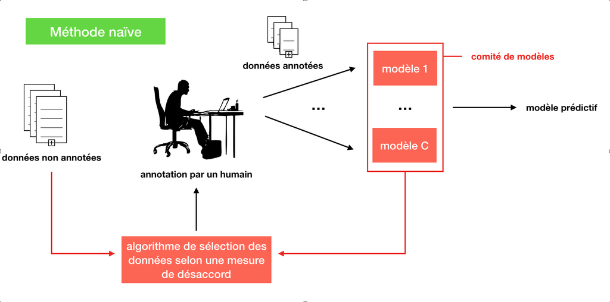

```python
Image("img/qbc_process.png", width=800, height=200)
```

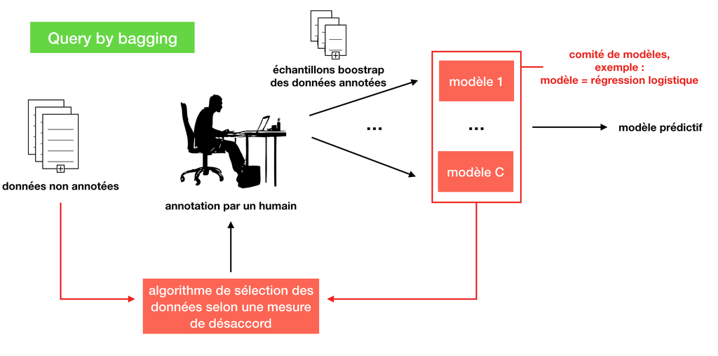

```python
Image("img/qbag_process.png", width=800, height=200)
```

**2. Quelle mesure de désaccord choisir ?**

- Il existe différentes approches pour mesurer le désaccord. Nous allons seulement présenter les deux méthodes les plus connues :
  - Le **vote entropy** (Dagon et Engelson, 1995) vue comme une généralisation de $x_{H}^*$ :

    $$x_{VE}^* = \arg\max_{x \in \mathcal{U}}\left\{ - \sum\limits_{i=1}^{|\mathcal{C}|}\frac{V(y_i)}{N} \ \log \frac{V(y_i)}{N} \right\}$$

    où $N$ est la taille de la comité et $V(y_i)$ le nombre de vote pour la classe $y_i$.
  - La **divergence moyenne de Kullback Leibler** (MacCallum et Nigam, 1998) :

    $$x_{KL}^* = \frac{1}{N} \sum\limits_{i=1}^{N} D(P_{\theta^{(i)}} \ || \ P_N )$$

    où $D(P_{\theta^{(i)}} \ || \ P_N ) = \sum\limits_{j=1}^{|\mathcal{C}|}P_{\theta^{(i)}}(y_j \ | \ x)\log \frac{P_{\theta^{(i)}}(y_j \ | \ x)}{P_N(y_j \ | \ x)}$

    avec $P_{N}(y_j \ | \ x) = \frac{1}{N}\sum_{j=1}^{|\mathcal{C}|}P_{\theta^{(i)}}(y_j \ | \ x)$

## 4. Expérimentations

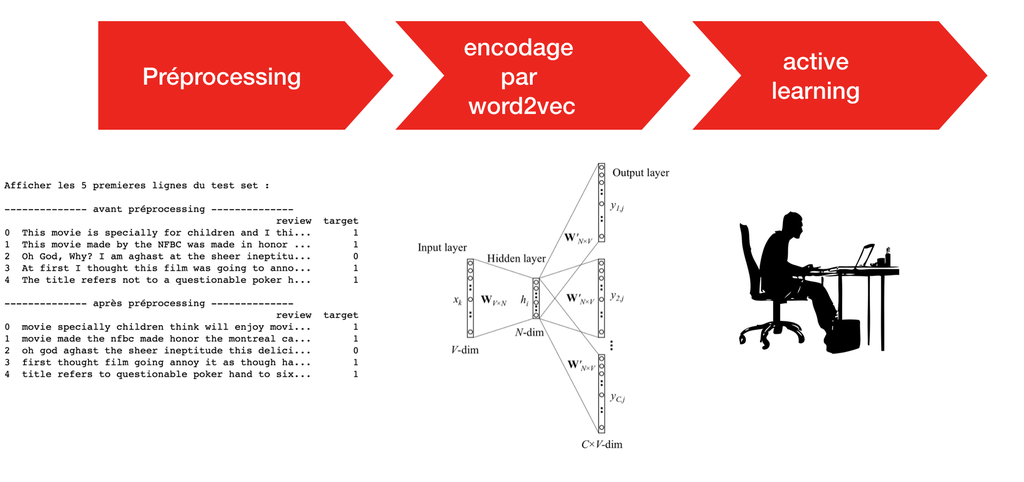

```python
Image("img/exp3.png", width=800, height=200)
```

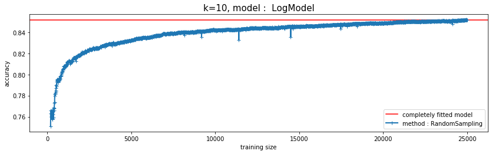

```python
Image("img/res_log_pre.png", width=800, height=200)
```

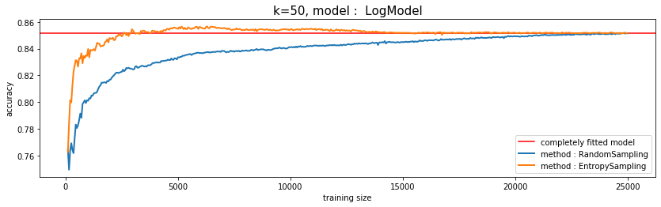

```python
Image("img/res_log.png", width=800, height=200)
```

**résumé** :

- **Active learning**
- deux méthodes classiques : **échantillonnage incertain, échantillonnage basé sur le désaccord**
- par rapport à un échantillonnage aléatoire, nous pouvons obtenu la même performance du modèle tout en **réduisant considérablement la taille des données d'apprentissage**

## Conclusion

- **préprocessing** des données textuelles
- NLP dans un **contexte non-supervisé** : word embedding, topic modeling
- NLP dans un **contexte supervisé** : RNN, DRNN, BRNN, LSTM, GRU
- NLP dans un **contexte semi-supervisé** : active learning pour la classification de texte